# Economic Growth

Session 2

Luis F. Gómez L.

luis.gomezl@unimilitar.edu.co

Distance Learning Faculty

29 January, 2026

# Please Read Me

- Check the message **Welcome greeting** published in Announcements forum.
- Dear student please edit your profile uploading a photo where your face is clearly visible.
- If you want to participate, please fill out the following survey: **Primer corte 30% > Learning Activities > Tu opinión sobre la economía colombiana**
- This presentation is based on (Cardenas, 2020, Chapter 3)
- **Purpose**
  - Analyze the determinants of economic growth

# Inputs to obtain GDP

Gross domestic product is obtained by using the following inputs:

- Labor
  - Quantity of labor:
    - Employment[^1]
    - Hours worked
  - Quality of Labor:
    - Employment by educational attainment
    - Compensation by educational attainment

Gross domestic product is obtained by using the following inputs[^2]:

- Produced non-financial fixed assets[^3]
  - Dwellings
  - Other buildings and structures
    - Buildings other than dwellings
    - Other structures
    - Land improvements
  - Machinery and equipment
    - Transport equipment
    - Information and Computer Technology (ICT) equipment
    - Other machinery and equipment
  - Weapons systems
  - Cultivated biological resources

Other factors that affect the Gross Domestic Product different from labor and produced non-financial fixed assets

- These factors are not directly observable but are used in growth accounting to calculate **Total Factor Productivity/Multifactor productivity** as an approximation to technological change
  - Technological change is defined as changes in the Gross Domestic Product that are not due to changes in inputs

# Growth accounting

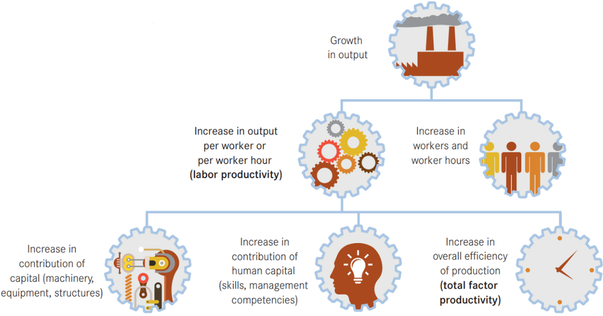

Figure 1: Labor productivity and total factor productivity (Vries & Azeez Erumban, 2022, p. 21, fig 6)

Table 1: Growth accounting applied to Colombia for selected years

| Measure | 1990 | 2010 | 2020 | 2025 |
| --- | --- | --- | --- | --- |
| Growth in real GDP | 4.08 | 4.40 | -7.46 | 2.40 |
| Contribution of Labor Quantity to real GDP growth | 1.43 | 1.94 | -13.53 | 0.00 |
| Contribution of Labor Quality to real GDP growth | 0.80 | 1.08 | 1.97 | 0.22 |
| Contribution of Total Capital Services to real GDP growth | 1.24 | 2.49 | 0.83 | 0.96 |
| Growth of Total Factor Productivity | 0.62 | -1.12 | 3.28 | 1.22 |

Source: Total Economy Database - Growth Accounting and Total Factor Productivity  
Last update: 2026-01-29

# Case study: number of hours worked

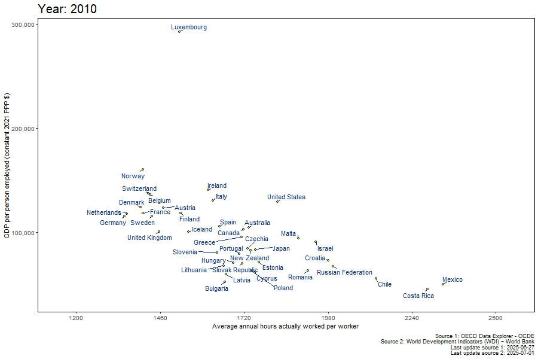

# Proximate and fundamental determinants of economic growth

- Proximate determinants
  - Increase in workers and worked hours
  - Increase in produced non-financial fixed assets
  - Increase in educational attainment, experience and skills (lifelong learning)
  - Increase in overall efficiency of production (total factor productivity)
- Fundamental determinants
  - Better institutions (Cardenas, 2020, Chapter 4)
  - Integration into the global economy (Cardenas, 2020, Chapter 5)
  - Geographical conditions

# Acknowledgments

- To my family that supports me
- To the taxpayers of Colombia and the [**UMNG students**](https://www.umng.edu.co/estudiante) who pay my salary
- To the [**Business Science**](https://www.business-science.io/) and [**R4DS Online Learning**](https://www.rfordatasci.com/) communities where I learn [**R**](https://www.r-project.org/about.html) and [**$\pi$-thon**](https://www.python.org/about/)
- To the [**R Core Team**](https://www.r-project.org/contributors.html), the creators of [**RStudio IDE**](https://posit.co/download/rstudio-desktop/), [**Positron**](https://positron.posit.co/), [**Quarto**](https://quarto.org/) and the authors and maintainers of the packages [**tidyverse**](https://CRAN.R-project.org/package=tidyverse), [**readxl**](https://CRAN.R-project.org/package=readxl), [**wbstats**](https://CRAN.R-project.org/package=wbstats), [**janitor**](https://CRAN.R-project.org/package=janitor), [**ggrepel**](https://CRAN.R-project.org/package=ggrepel), [**gt**](https://CRAN.R-project.org/package=gt), [**wbstats**](https://CRAN.R-project.org/package=wbstats), [**scales**](https://CRAN.R-project.org/package=scales), [**gganimate**](https://CRAN.R-project.org/package=gganimate) and [**tinytex**](https://CRAN.R-project.org/package=tinytex) for allowing me to access these tools without paying for a license

# References

Cardenas, M. (2020). *Introducción a la Economía Colombiana* (4th ed.). Alfaomega.

OECD. (2001). *Measuring Productivity - OECD Manual: Measurement of Aggregate and Industry-level Productivity Growth*. OECD. https://doi.org/10.1787/9789264194519-en

OECD. (2009). *Measuring Capital - OECD Manual 2009: Second edition*. OECD. https://doi.org/10.1787/9789264068476-en

United Nations, European Commission, International Monetary Fund, Organisation for Economic Co-operation and Development, & World Bank (Eds.). (2009). *System of national accounts 2008*. United Nations. https://unstats.un.org/unsd/nationalaccount/sna2008.asp

Vries, K. de, & Azeez Erumban, A. (2022). *Total Economy Database: A detailed guide to its sources and methods*. https://conference-board.org/data/economydatabase/total-economy-database-methodology

## Footnotes

[^1]: Includes individuals employed aged 15 years or over where this age range is necessary for international comparisons.
[^2]: These categories are taken from (United Nations et al., 2009, p. 555)
[^3]: Other non-financial assets can be included but these are the ones that are usually measured. For more information check out (OECD, 2009) and (OECD, 2001)